# R Notebook

A.Gestin

Important note: it is currently designed to be applied on living cells only with compensated data (flowJo) this workflow depends on packages: flowCore, flowWorkspace, flowTrans, ggplot2, ggridges, reshape2, rlist, stringr, Rlist, RphenoGraph, Rtsne and umap

WORKFLOW : ---- This workflow is desgined for transforming aligning and clustering multiple flowcytometry data (.fcs) ----

-Import/install packages -some are probably missing, it will be patched.

-Reads in the data

-Subsets

-Transform the data (3 transformations available: choose the biexp chunck for comparing multiple datasets, the others allows experimented R users to analyse each file separately) -show a multiple densityplot that represents the data distribution

-t-sne representations -sample and markers intensities.

-clustering -Phenograph & flowSOM available -get informations about the clustering

-Manual association -visualize given informations§ -perform correlation cell by cell (with required normalization methods)

-Train a randomForest classifier

## Import the required libraries

This chunck import the data. (Here is a particular example only area channels were available in one of the file. This example besides shows how to concatenate).

## Subsetting

These chuncks allows you to subset the data. It is usefull for scaling experiments or lighten the data. User have to set the "desired_size" value and run the last chunck

This chunck allows you to set the subsampling size to the number of cells in the smallest sample

Subsets the data

check files names

```r
sampleNames(exp)
```

```
[1] "2020-03-06- export_bioinfo_3450c_livecells.fcs"      "2020-03-06- export_bioinfo_AIW_livecells.fcs"        "2020-03-06- export_bioinfo_AJG_livecells.fcs"
[4] "2020-03-17- export_bioinfo_old3450c_livecells.fcs"   "2020-03-17- export_bioinfo_oldAIW_livecells.fcs"     "2020-03-17- export_bioinfo_oldAJG_livecells.fcs"
[7] "2020-03-17- export_bioinfo_young3450c_livecells.fcs" "2020-03-17- export_bioinfo_youngAIW_livecells.fcs"   "2020-03-17- export_bioinfo_youngAJG_livecells.fcs"
```

Rename the files (optional)

```r
sampleNames(exp)<-c("3450c2","AIW2","AJG2","3450c1","3450c3","AIW1","AIW3","AJG1","AJG3")
sampleNames(exp)
```

```
[1] "3450c2" "AIW2"   "AJG2"   "3450c1" "3450c3" "AIW1"   "AIW3"   "AJG1"   "AJG3"
```

+++++ ADD RENAME MARKERS WITH INPUT +++++++

still to be added

## Transformation Step (Key step)

Just choose one

This one (with default parameters) is sensibly the same as biexp with default parameters. Those transformations gives equivalent results on clustering or manual gating

Call densityplots of two flowsets

```
Ignoring unknown parameters: verbose
```

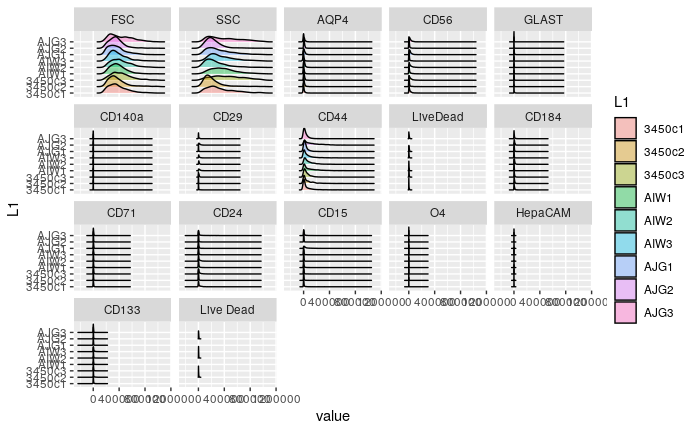

```r
# see plots
plotdensity_flowset(rename_markers(exp))
```

```r
plotdensity_flowset(rename_markers(expbe))
```

```
Ignoring unknown parameters: verbose
```

```r
# save plot
png(file="densityplot_expbe_rename.png",width=900*1.618,height=700)
```

```r
plotdensity_flowset(rename_markers(expbe))
```

```
Ignoring unknown parameters: verbose
```

[figure not shown]

```r
dev.off()
```

Now that the data is transformed, the intensities are distributed in an interpretable way. We can begin the alignment.

This gives an insight on the markers and their associated column in each .fcs file. Be carefull : the non consistency of marker names can lead to errors in the following steps. (visualize the caracteristic values of intensities per clusters)

```r
getmarkersinfo(rename_markers(exp))
```

```
[1] "Columns"
       $P1S  $P4S  $P7S   $P8S   $P9S    $P10S    $P11S  $P12S  $P13S       $P14S   $P15S  $P16S  $P17S  $P18S $P19S     $P20S
3450c2 "FSC" "SSC" "AQP4" "CD56" "GLAST" "CD140a" "CD29" "CD44" "Live Dead" "CD184" "CD71" "CD24" "CD15" "O4"  "HepaCAM" "CD133"
AIW2   "FSC" "SSC" "AQP4" "CD56" "GLAST" "CD140a" "CD29" "CD44" "Live Dead" "CD184" "CD71" "CD24" "CD15" "O4"  "HepaCAM" "CD133"
AJG2   "FSC" "SSC" "AQP4" "CD56" "GLAST" "CD140a" "CD29" "CD44" "Live Dead" "CD184" "CD71" "CD24" "CD15" "O4"  "HepaCAM" "CD133"
3450c1 "FSC" "SSC" "AQP4" "CD56" "GLAST" "CD140a" "CD29" "CD44" "LiveDead"  "CD184" "CD71" "CD24" "CD15" "O4"  "HepaCAM" "CD133"
3450c3 "FSC" "SSC" "AQP4" "CD56" "GLAST" "CD140a" "CD29" "CD44" "LiveDead"  "CD184" "CD71" "CD24" "CD15" "O4"  "HepaCAM" "CD133"
AIW1   "FSC" "SSC" "AQP4" "CD56" "GLAST" "CD140a" "CD29" "CD44" "LiveDead"  "CD184" "CD71" "CD24" "CD15" "O4"  "HepaCAM" "CD133"
AIW3   "FSC" "SSC" "AQP4" "CD56" "GLAST" "CD140a" "CD29" "CD44" "LiveDead"  "CD184" "CD71" "CD24" "CD15" "O4"  "HepaCAM" "CD133"
AJG1   "FSC" "SSC" "AQP4" "CD56" "GLAST" "CD140a" "CD29" "CD44" "LiveDead"  "CD184" "CD71" "CD24" "CD15" "O4"  "HepaCAM" "CD133"
AJG3   "FSC" "SSC" "AQP4" "CD56" "GLAST" "CD140a" "CD29" "CD44" "LiveDead"  "CD184" "CD71" "CD24" "CD15" "O4"  "HepaCAM" "CD133"
[1] "Column and associated ID"
       $P1N    $P4N    $P7N           $P8N           $P9N           $P10N          $P11N          $P12N          $P13N          $P14N          $P15N
3450c2 "FSC-A" "SSC-A" "FJComp-BL1-A" "FJComp-BL2-A" "FJComp-RL1-A" "FJComp-RL2-A" "FJComp-RL3-A" "FJComp-VL1-A" "FJComp-VL2-A" "FJComp-VL3-A" "FJComp-VL4-A"
AIW2   "FSC-A" "SSC-A" "FJComp-BL1-A" "FJComp-BL2-A" "FJComp-RL1-A" "FJComp-RL2-A" "FJComp-RL3-A" "FJComp-VL1-A" "FJComp-VL2-A" "FJComp-VL3-A" "FJComp-VL4-A"
AJG2   "FSC-A" "SSC-A" "FJComp-BL1-A" "FJComp-BL2-A" "FJComp-RL1-A" "FJComp-RL2-A" "FJComp-RL3-A" "FJComp-VL1-A" "FJComp-VL2-A" "FJComp-VL3-A" "FJComp-VL4-A"
3450c1 "FSC-A" "SSC-A" "FJComp-BL1-A" "FJComp-BL2-A" "FJComp-RL1-A" "FJComp-RL2-A" "FJComp-RL3-A" "FJComp-VL1-A" "FJComp-VL2-A" "FJComp-VL3-A" "FJComp-VL4-A"
3450c3 "FSC-A" "SSC-A" "FJComp-BL1-A" "FJComp-BL2-A" "FJComp-RL1-A" "FJComp-RL2-A" "FJComp-RL3-A" "FJComp-VL1-A" "FJComp-VL2-A" "FJComp-VL3-A" "FJComp-VL4-A"
AIW1   "FSC-A" "SSC-A" "FJComp-BL1-A" "FJComp-BL2-A" "FJComp-RL1-A" "FJComp-RL2-A" "FJComp-RL3-A" "FJComp-VL1-A" "FJComp-VL2-A" "FJComp-VL3-A" "FJComp-VL4-A"
AIW3   "FSC-A" "SSC-A" "FJComp-BL1-A" "FJComp-BL2-A" "FJComp-RL1-A" "FJComp-RL2-A" "FJComp-RL3-A" "FJComp-VL1-A" "FJComp-VL2-A" "FJComp-VL3-A" "FJComp-VL4-A"
AJG1   "FSC-A" "SSC-A" "FJComp-BL1-A" "FJComp-BL2-A" "FJComp-RL1-A" "FJComp-RL2-A" "FJComp-RL3-A" "FJComp-VL1-A" "FJComp-VL2-A" "FJComp-VL3-A" "FJComp-VL4-A"
AJG3   "FSC-A" "SSC-A" "FJComp-BL1-A" "FJComp-BL2-A" "FJComp-RL1-A" "FJComp-RL2-A" "FJComp-RL3-A" "FJComp-VL1-A" "FJComp-VL2-A" "FJComp-VL3-A" "FJComp-VL4-A"
       $P16N          $P17N          $P18N          $P19N          $P20N
3450c2 "FJComp-VL5-A" "FJComp-VL6-A" "FJComp-YL1-A" "FJComp-YL2-A" "FJComp-YL3-A"
AIW2   "FJComp-VL5-A" "FJComp-VL6-A" "FJComp-YL1-A" "FJComp-YL2-A" "FJComp-YL3-A"
AJG2   "FJComp-VL5-A" "FJComp-VL6-A" "FJComp-YL1-A" "FJComp-YL2-A" "FJComp-YL3-A"
3450c1 "FJComp-VL5-A" "FJComp-VL6-A" "FJComp-YL1-A" "FJComp-YL2-A" "FJComp-YL3-A"
3450c3 "FJComp-VL5-A" "FJComp-VL6-A" "FJComp-YL1-A" "FJComp-YL2-A" "FJComp-YL3-A"
AIW1   "FJComp-VL5-A" "FJComp-VL6-A" "FJComp-YL1-A" "FJComp-YL2-A" "FJComp-YL3-A"
AIW3   "FJComp-VL5-A" "FJComp-VL6-A" "FJComp-YL1-A" "FJComp-YL2-A" "FJComp-YL3-A"
AJG1   "FJComp-VL5-A" "FJComp-VL6-A" "FJComp-YL1-A" "FJComp-YL2-A" "FJComp-YL3-A"
AJG3   "FJComp-VL5-A" "FJComp-VL6-A" "FJComp-YL1-A" "FJComp-YL2-A" "FJComp-YL3-A"
[1] "Marker"
       $P1S    $P4S    $P7S                                 $P8S                 $P9S          $P10S                                  $P11S
3450c2 "FSC-A" "SSC-A" "AQP4-Alexa Fluor<e2><84><a2> 488-A" "CD56-PerCP-Cy5.5-A" "GLAST-APC-A" "CD140a-Alexa Fluor<e2><84><a2> 700-A" "CD29-APC-Cy7-A"
AIW2   "FSC-A" "SSC-A" "AQP4-Alexa Fluor<e2><84><a2> 488-A" "CD56-PerCP-Cy5.5-A" "GLAST-APC-A" "CD140a-Alexa Fluor<e2><84><a2> 700-A" "CD29-APC-Cy7-A"
AJG2   "FSC-A" "SSC-A" "AQP4-Alexa Fluor<e2><84><a2> 488-A" "CD56-PerCP-Cy5.5-A" "GLAST-APC-A" "CD140a-Alexa Fluor<e2><84><a2> 700-A" "CD29-APC-Cy7-A"
3450c1 "FSC-A" "SSC-A" "AQP4-Alexa Fluor<e2><84><a2> 488-A" "CD56-PerCP-Cy5.5-A" "GLAST-APC-A" "CD140a-Alexa Fluor<e2><84><a2> 700-A" "CD29-APC-Cy7-A"
3450c3 "FSC-A" "SSC-A" "AQP4-Alexa Fluor<e2><84><a2> 488-A" "CD56-PerCP-Cy5.5-A" "GLAST-APC-A" "CD140a-Alexa Fluor<e2><84><a2> 700-A" "CD29-APC-Cy7-A"
AIW1   "FSC-A" "SSC-A" "AQP4-Alexa Fluor<e2><84><a2> 488-A" "CD56-PerCP-Cy5.5-A" "GLAST-APC-A" "CD140a-Alexa Fluor<e2><84><a2> 700-A" "CD29-APC-Cy7-A"
```

[output cut: 8 more lines]

```
3450c3 "CD44-Brilliant Violet 421-A" "LiveDead-Fixable Aqua-A"  "CD184-Brilliant Violet 605-A" "CD71-Brilliant Violet 650-A" "CD24-Brilliant Violet 711-A"
AIW1   "CD44-Brilliant Violet 421-A" "LiveDead-Fixable Aqua-A"  "CD184-Brilliant Violet 605-A" "CD71-Brilliant Violet 650-A" "CD24-Brilliant Violet 711-A"
AIW3   "CD44-Brilliant Violet 421-A" "LiveDead-Fixable Aqua-A"  "CD184-Brilliant Violet 605-A" "CD71-Brilliant Violet 650-A" "CD24-Brilliant Violet 711-A"
AJG1   "CD44-Brilliant Violet 421-A" "LiveDead-Fixable Aqua-A"  "CD184-Brilliant Violet 605-A" "CD71-Brilliant Violet 650-A" "CD24-Brilliant Violet 711-A"
AJG3   "CD44-Brilliant Violet 421-A" "LiveDead-Fixable Aqua-A"  "CD184-Brilliant Violet 605-A" "CD71-Brilliant Violet 650-A" "CD24-Brilliant Violet 711-A"
       $P17S                         $P18S       $P19S                                $P20S
3450c2 "CD15-Brilliant Violet 786-A" "O4-R-PE-A" "HepaCAM-PE-Texas Red<e2><84><a2>-A" "CD133-PE-Cy7-A"
AIW2   "CD15-Brilliant Violet 786-A" "O4-R-PE-A" "HepaCAM-PE-Texas Red<e2><84><a2>-A" "CD133-PE-Cy7-A"
AJG2   "CD15-Brilliant Violet 786-A" "O4-R-PE-A" "HepaCAM-PE-Texas Red<e2><84><a2>-A" "CD133-PE-Cy7-A"
3450c1 "CD15-Brilliant Violet 786-A" "O4-R-PE-A" "HepaCAM-PE-Texas Red<e2><84><a2>-A" "CD133-PE-Cy7-A"
3450c3 "CD15-Brilliant Violet 786-A" "O4-R-PE-A" "HepaCAM-PE-Texas Red<e2><84><a2>-A" "CD133-PE-Cy7-A"
AIW1   "CD15-Brilliant Violet 786-A" "O4-R-PE-A" "HepaCAM-PE-Texas Red<e2><84><a2>-A" "CD133-PE-Cy7-A"
AIW3   "CD15-Brilliant Violet 786-A" "O4-R-PE-A" "HepaCAM-PE-Texas Red<e2><84><a2>-A" "CD133-PE-Cy7-A"
AJG1   "CD15-Brilliant Violet 786-A" "O4-R-PE-A" "HepaCAM-PE-Texas Red<e2><84><a2>-A" "CD133-PE-Cy7-A"
AJG3   "CD15-Brilliant Violet 786-A" "O4-R-PE-A" "HepaCAM-PE-Texas Red<e2><84><a2>-A" "CD133-PE-Cy7-A"
```

## Alignment

This chunck perform the alignment of the densitypeaks. It requires 2 calls of the function depending on the shape of the distribution. The plotting allows to be sure that the alignment performed well. If not, rerun the chunck by changing the peak.density.thr and the associated columns (2nd arg) for the alignment with 1 peak and for the alignment with 2 peaks.

```r
png(file=file_name, width=900*1.618,height=700)
grid.arrange(dp_expbe, dp_expbe_al, nrow = 1)
dev.off()
```

This chunck allows to perform and plot a tsne with all usual parameters.

Warning: colstoignore corresponds to the markers to ignore. (Usually get rid of the LiveDead marker and size markers (FSC SSC - respectively 1 and 2) - debatable). If you don't know the corresponding columns, you can access the marker names by calling the flowCore function 'markernames(flowset)' (remember that FSC and SSC are not considered as markers and do not appears in the list) or 'getmarkersinfo(flowset)' for more informations

```r
object_name = paste(save_path,"Aug7_2020_" ,"tSNE_expbe_9col_1500_cells.Rdata",sep="")
saveRDS
```

[output not shown]

If you prefer umap, it has to be adapted for more figures.

```r
umap_expbe=umap_flowset(expbe_al,colstoignore=c(9),scale=TRUE)
plot_umap(umap_expbe,"hasar")
```

------- Just for "fun", a 3D tsne ---------

```r
# this should be taken out or changed to the flow data

library(car)
library(rgl)
tsne_expbe30=tsne_flowset(expbe_al,scale=TRUE,colstoignore = c(9) ,dims = 3, perplexity=30,theta=0.5, verbose=FALSE, max_iter = 1000,eta=500)
colors=c("deepskyblue1","orange","violetred2","maroon2","brown2","dodgerblue","cyan","yellow3","darkgoldenrod2","brown3","maroon2","violetred2")
expcounts=fsApply(exp,function(x){nrow(x)})
cols3d=c()
for (i in 1:length(expcounts)){
  cols3d=append(cols3d, rep(colors[i],expcounts[i]))
}
scatter3d(x=tsne_expbe30$Y[,1],y=tsne_expbe30$Y[,2],z=tsne_expbe30$Y[,3],point.col=cols3d,surface=FALSE)
```

Clustering

This chunck performs the Phenograph clustering and save the results in a variable. Another chunck will read this variable to get informations about the clustering results. Rphenograph_flowset(flowet,columns to ignore, k, scale (boolean)). Based on litterature, golden standard is to not consider FSC and SSC channels, nor the Live - Dead channel (if present). K corresponds to the initial K-NN graph computed by the phenograph method. Lower values of k yield a greater number of groups.

```r
# this function will take a long time to run. The computation lenght increases with cell number
pheno_expbe_al=Rphenograph_flowset(expbe_al,colstoignore=c(1,2,9),k=250,scale=TRUE) #Apply the function
```

```
Run Rphenograph starts:
  -Input data of 14202 rows and 13 columns
  -k is set to 250
```

```
  Finding nearest neighbors...DONE ~ 6.402 s
  Compute jaccard coefficient between nearest-neighbor sets...DONE ~ 288.21 s
  Build undirected graph from the weighted links...DONE ~ 12.234 s
  Run louvain clustering on the graph ...DONE ~ 13.941 s
```

```
Run Rphenograph DONE, totally takes 320.786999999998s.
```

```
  Return a community class
  -Modularity value: 0.8657423
  -Number of clusters: 19
```

```r
# save the clustered object
object_name = paste(save_path,"Aug7_2020_" ,"pheno_expbe_al_expbe__k250_9col_1500_cells.Rdata",sep="")
saveRDS(pheno_expbe_al,object_name)
# load the saved object
#pheno_expbe_al <- readRDS(object_name)
```

This chunck performs the flowSOM clustering (faster) and save the results in a variable. Another chunck will read this variable to get informations about the clustering results. You can have more information about the parameters by typing "?FlowSOM" in the R console. You can define a number of clusters by adding "nClus" in the parameters of the FlowSOM function

```r
library(FlowSOM)
flowSOM.clustering=GetMetaclusters(FlowSOM(expbe_al,pattern=".fcs",transform=FALSE, compensate = FALSE, spillover = NULL,colsToUse =  c(3:8,10:16),maxMeta = 30,nClus = 25 ))

plot_tsne_clust(tsne_expbe,flowSOM.clustering,"flowSOM clustering result")
```

This chunck provides a plots and information about the clustering (number of cells per sample per cluster and mean values)

```r
png(file= (paste(save_path,"heatmap_Rpheno_k250.png",sep="")),width=1000*1.618,height=1000)
hmap1
dev.off()
```

do.call("grid.arrange", c(myplots, ncol=nCol))

# To assign these clusters to cell profiles automatically use the following chunck. User need to import an expected expression table by phenotype

```r
# load the reference table
reference_table = "/home/rhalena/Documents/Documents/MyPapers/FACS/Analysis/ManualAnalysis/ExpessionCellPhenotypeTable3.csv"
norm_cellpheno=read.csv(file= reference_table)
#norm_cellpheno=read.csv(file="/home/alx/Documents/McGill_Neuro/Datasets/FACS_Paper/ExpessionCellPhenotypeTable3.csv")
cluster_correlation_by_cell=correlation_cluster_celltype(expbe_al,membership(pheno_expbe_al[[2]]),norm_cellpheno,c(1,2,9))
```

[output not shown]

This chunck gives several insight on the association of clusters

```r
summary_correlation_by_cluster
assigned_celltype
```

# The two following chuncks allows the user to define its own association.

The first one give the order of the clusters to rename & the second one takes the user input and creates the association.

```r
unique(pheno_expbe_al[[2]]$membership)
```

```
 [1]  5  7  8 19 18 17 14  2 15 12 11  6 13  1  3 10 16  4  9
```

```r
user_celltypes<-c("Neuron","Treize","Six","Huit","Cinq","Quinze","Quatorze","Trois","Onze","Sept","Deux","Neuf","Seize","Quatre","Un")

assigned_celltype=NULL
assigned_celltype[paste0("cluster_",unique(pheno_expbe_al[[2]]$membership))]=user_celltypes
```

This chunck creates the list of assignigned cell type of each cell that will eventually be used by the classifier.

```r
list_of_celltypes=as.vector(assigned_celltype[paste0("cluster_",pheno_expbe_al[[2]]$membership)])
```

## RandomForest classifier

This chunck extract the values to use for the classifier and associates the previous "list_of_celltypes". We strongly recommand to get rid of the same columns

```r
library(randomForest)

facsdata=list.rbind(lapply(as.list(rename_markers(expbe_al)@frames),function(x){x=as.data.frame(x@exprs[,-c(1,2,9)])}))
facsdata$assigned_celltype<-as.factor(as.character(list_of_celltypes))
```

# This chunck train a randomForest classifier with all the data

```r
rf_classifier_model<-randomForest(assigned_celltype~ . , data=facsdata,proximity=TRUE,ntree=250)
rf_classifier_model
importance(rf_classifier_model)
```

To predict, here's the same example with the same dataset divided in training and test dataset

```r
#Separate the data in 2 groups with 70% of training data
set.seed(42)
ind = sample(2, nrow(facsdata), replace=TRUE, prob=c(0.7,0.3))
trainData = facsdata[ind==1,]
testData = facsdata[ind==2,]

#Train the model with training data
rf_classifier_model = randomForest(assigned_celltype~ . , data=trainData, ntree=100, proximity=T)

#Prediction with training data
table(predict(rf_classifier_model), trainData$assigned_celltype)


testData$assigned_celltype<-NA
#Prediction with test data
predicted_pheno = predict(rf_classifier_model, newdata=testData)
confusion_matrix=table(irisPred, testData$assigned_celltype)
```

```r
oob.err.data=data.frame(Trees=rep(1:nrow(rf_classifier_model$err.rate),times=ncol(rf_classifier_model$err.rate)),
                        Type=rep(c(colnames(rf_classifier_model$err.rate)),each=nrow(rf_classifier_model$err.rate)),
                        Error=as.vector(apply(rf_classifier_model$err.rate,2,function(x){x})))

ggplot(oob.err.data,aes(x=Trees,y=Error))+geom_line(aes(color=Type))+theme_minimal()
```

-----MANUAL ASSIGNATION-----

Read and compare zscore-normalized values of expected cell types to the zscore-normalized values of each cell

This chunck load and represents with a heatmap the given expected values for different phenotypes. We expect these values being between 0 and 1

```r
norm_cellpheno=read.csv(file="/home/alx/Documents/McGill_Neuro/Datasets/FACS_Paper/ExpessionCellPhenotypeTable3.csv")

cellpheno=norm_cellpheno[,c(2:ncol(norm_cellpheno))]
cellpheno$X=as.factor(cellpheno$X)
mlt_cellpheno=melt(cellpheno)
colnames(mlt_cellpheno)<-c("marker","phenotype","value")
#png(file="/home/alx/Documents/McGill_Neuro/Scripts/FACS_clustering/phenotype_heatmap",width=400*1.618,height=400)
ggplot(mlt_cellpheno,aes(x=phenotype,y=marker,fill=value))+geom_tile(size=0.5)+  scale_fill_gradient2(mid="steelblue2", high ="maroon2",breaks=c(0.2,0.8),labels=c("Low","High"), na.value = "grey50")+scale_x_discrete(position = "top")
#dev.off()
```

```r
rename_expbe_al=rename_markers(expbe_al)
facsdata=lapply(as.list(rename_expbe_al@frames),function(x){x=as.data.frame(x@exprs[,-c(1,2,9)])})
binded_facs_data=list.rbind(facsdata)

binded_expr=as.data.frame(scale(as.matrix(binded_facs_data),scale=TRUE,center=TRUE))

binded_expr=as.data.frame(apply(binded_expr,2, minmax_normalize))

norm_cellpheno[is.na(norm_cellpheno)]=0

rownames(norm_cellpheno)=toupper(norm_cellpheno$X)
colnames(binded_expr)=toupper(colnames(binded_expr))

intersect_markers=intersect(colnames(binded_expr),rownames(norm_cellpheno))
intersect_markers=intersect_markers[order(intersect_markers)]

norm_cellpheno=norm_cellpheno[intersect_markers,]
binded_expr=binded_expr[,intersect_markers]

corlist=t(apply(as.data.frame(binded_expr),1, assigntype, norm_cellpheno))

colnames(corlist)=colnames(norm_cellpheno[,3:ncol(norm_cellpheno)])

assignation=apply(corlist,1,function(x){
  max=max(x)
  if (max!=abs(max)){
    return("Unassigned")
  }
  else{
    return(colnames(corlist)[which.max(x)])
  }
})

values=list()
values$correlation=apply(corlist,1,function(x){max(x)})
values$assignation=assignation
values=as.data.frame(values)
values$assignation=as.factor(values$assignation)


data_summary <- function(x) {
   m <- mean(x)
   ymin <- m-sd(x)
   ymax <- m+sd(x)
   return(c(y=m,ymin=ymin,ymax=ymax))
}

ggplot(values,aes(x=assignation,y=correlation,color=assignation))+geom_violin(trim = FALSE) + stat_summary(fun.data=data_summary)+scale_color_manual(values = c("#36dee6", # bright blue
            "#6d71d8", # blue
            "#5c3788", # dark purple blue
            "#b1457b", # purple
            "#ca73c6", # other purple
            "#006400", # dark green
            "#54b06c", # green
            "#799e43", # olive green
            "#c1a339", # yellow mustard
            "#b86738", # orange
            "Khaki3",
            "brown3",
            "darkgrey"))


tohm=cbind(as.data.frame(list.rbind(lapply(as.list(expbe_al@frames),function(x){x@exprs[,-c(1,2,9)]}))),as.factor(assignation))
tohm=tohm[order(tohm$`as.factor(assignation)`),]
tohm$cell=as.factor(c(1:nrow(tohm)))
totohm=as.data.frame(melt(tohm))
colnames(totohm)<-c("cluster","cell","marker","value")
totohm=totohm[order(totohm$cluster),]


ggplot(as.data.frame(assignation),aes(assignation,fill=assignation))+geom_histogram(stat="count")+scale_fill_manual(values = c("#36dee6", # bright blue
            "#6d71d8", # blue
            "#5c3788", # dark purple blue
            "#b1457b", # purple
            "#ca73c6", # other purple
            "#006400", # dark green
            "#54b06c", # green
            "#799e43", # olive green
            "#c1a339", # yellow mustard
            "#b86738", # orange
            "Khaki3",
            "brown3",
            "darkgrey"))
```

SOME PLOTS assignment=assignation

ggplot(as.data.frame(tsne_expbe$Y)) + geom_point(aes(x=tsne_expbe$Y[,1], y=tsne_expbe$Y[,2],col=sample),size=0.5)+ guides(colour = guide_legend(override.aes = list(size=3)))+ scale_colour_manual(values = c("#36dee6", # bright blue "#6d71d8", # blue "#5c3788", # dark purple blue "#b1457b", # purple "#ca73c6", # other purple "#006400", # dark green "#54b06c", # green "#799e43", # olive green "#c1a339", # yellow mustard "#b86738", "red"))+ggtitle("t-sne 9 organoids with 1578 cells each")

ggplot(as.data.frame(tsne_expbe$Y)) + geom_point(aes(x=tsne_expbe$Y[,1], y=tsne_expbe$Y[,2],col=as.factor(membership(pheno_expbe_al[[2]]))),size=0.5)+ guides(colour = guide_legend(override.aes = list(size=3)))+ scale_colour_manual(values = c("#36dee6", # bright blue "#6d71d8", # blue "#5c3788", # dark purple blue "#b1457b", # purple "#ca73c6", # other purple "#006400", # dark green "#54b06c", # green "#799e43", # olive green "#c1a339", # yellow mustard "#b86738" ,"darkorchid3","chocolate","chartreuse3","bisque3","aquamarine2","mediumspringgreen","peru","peachpuff4","yellowgreen","thistle2","olivedrab1","powderblue","rosybrown1","rosybrown3","lawngreen","mistyrose","gold4", "red"))+ggtitle("t-sne 9 organoids with 1578 cells each")

ggplot(values,aes(x=assignment,y=correlation,color=assignment))+geom_violin(trim = FALSE) + stat_summary(fun.data=data_summary)+scale_color_manual(values = c("#36dee6", # bright blue "#6d71d8", # blue "#5c3788", # dark purple blue "#b1457b", # purple "#ca73c6", # other purple "#006400", # dark green "#54b06c", # green "#799e43", # olive green "#c1a339", # yellow mustard "#b86738", # orange "Khaki3", "brown3", "darkgrey"))+ggtitle("Pearson correlation score")

ggplot(totohm,aes(x=cell,y=marker,fill=value))+geom_raster(size=0.5)+ scale_fill_gradient2(low="cyan2", high ="darkorchid3")+scale_x_discrete(labels=totohm$cluster,position = "top")+theme(axis.text.x = element_blank())+facet_grid(~cluster,scales="free",drop=TRUE)+ggtitle("biexponential transformed aligned values of assigned cells")

ggplot(as.data.frame(assignment),aes(assignment,fill=assignment))+geom_histogram(stat="count")+scale_fill_manual(values = c("#36dee6", # bright blue "#6d71d8", # blue "#5c3788", # dark purple blue "#b1457b", # purple "#ca73c6", # other purple "#006400", # dark green "#54b06c", # green "#799e43", # olive green "#c1a339", # yellow mustard "#b86738", # orange "Khaki3", "brown3", "darkgrey"))

```r
comp2max<-function(corvalues){
  truemax=corvalues[which.max(corvalues)]
  intervalue=corvalues[-which.max(corvalues)]
  secondmax=intervalue[which.max(intervalue)]
  return(truemax-secondmax)
}

maxdiff=apply(corlist, 1,comp2max)
getmean=apply(corlist,1,function(x){mean(x)})
res=maxdiff-getmean

getmax=apply(corlist,1,function(x){max(x)})
```